# 21-explore-depression

## Missing Value Visualization for Depression

- All the missing values are from wave 5.

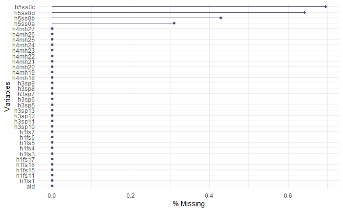

```r
depression %>%
  gg_miss_var(show_pct = T)
```

[figure not shown]

```r
hist_by_var <-function(df,vars, title = title){
  ggplot(gather(df[,which(colnames(df) %in% vars)]), aes(x= value)) +
    geom_bar(stat = 'count') +
    facet_wrap(~key, scales = 'free_x')+
    ggtitle(title)+
    theme_minimal()+
    theme(plot.title=element_text(hjust=0.5))
}
```

# Depression Variables

Visualization of how answers change for the same question over different waves.

```r
p1 <- hist_by_var(depression, c('h1fs1',"h3sp5","h4mh18"), "bothered by things")
```

```
attributes are not identical across measure variables;
they will be dropped
```

```r
p2 <- hist_by_var(depression, c("h1fs3","h3sp6","h4mh19","h5ss0a"), "shake off blues")
```

```
attributes are not identical across measure variables;
they will be dropped
```

```r
p3 <- hist_by_var(depression, c("h1fs4","h3sp7","h4mh20"), "felt as good as others")
```

```
attributes are not identical across measure variables;
they will be dropped
```

```r
p4 <- hist_by_var(depression, c("h1fs5","h3sp8","h4mh21"), "trouble concentrating")
```

```
attributes are not identical across measure variables;
they will be dropped
```

```r
p5 <- hist_by_var(depression, c("h1fs6","h3sp9","h4mh22",   "h5ss0b"), "felt depressed")
```

```
attributes are not identical across measure variables;
they will be dropped
```

```r
p6 <- hist_by_var(depression, c("h1fs7","h3sp10",   "h4mh23"), "felt too tired")
```

```
attributes are not identical across measure variables;
they will be dropped
```

```r
p7 <- hist_by_var(depression, c("h1fs11","h4mh24","h5ss0c"), "felt happy")
```

```
attributes are not identical across measure variables;
they will be dropped
```

```r
p8 <-hist_by_var(depression, c("h1fs15","h3sp11","h4mh25"), "enjoyed life")
```

```
attributes are not identical across measure variables;
they will be dropped
```

```r
p9 <-hist_by_var(depression, c("h1fs16","h3sp12","h4mh26","h5ss0d"), "felt sad")
```

```
attributes are not identical across measure variables;
they will be dropped
```

```r
p10 <- hist_by_var(depression, c("h1fs17","h3sp13","h4mh27"), "felt disliked")
```

```
attributes are not identical across measure variables;
they will be dropped
```

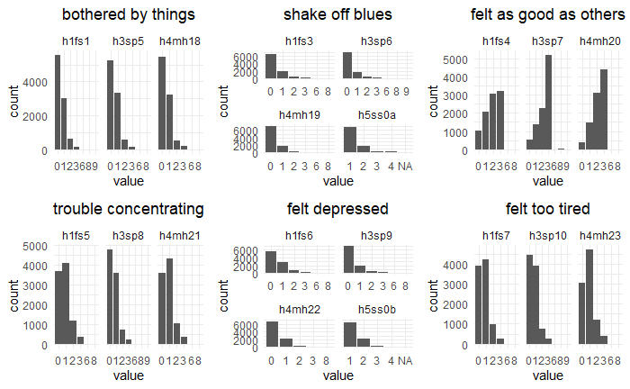

```r
grid.arrange(p1, p2, p3, p4, p5, p6, nrow = 2)
```

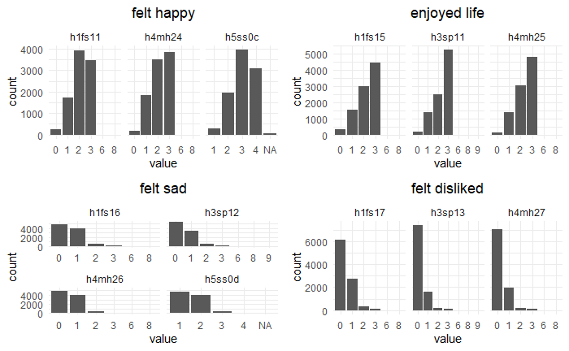

```r
grid.arrange(p7, p8, p9, p10, nrow = 2)
```

```r
NA
```

### Visualization of Wave 1 Variables and Survey Answers for those

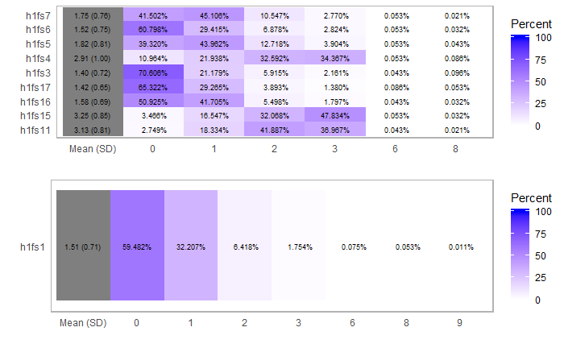

```r
depression_wave1 <- depression %>%
  dplyr::select(h1fs3,h1fs4,h1fs5,h1fs6,h1fs7,h1fs11,h1fs15,h1fs16,h1fs17)

depression_wave1_sub <- depression %>%
  dplyr::select(h1fs1)


p1 <- plot(likert(data.frame(depression_wave1)),
     type="heat",
           low.color = "white",
           high.color = "blue",
           text.color = "black",
           text.size = 2.5,
           wrap = 50)

p2 <- plot(likert(data.frame(depression_wave1_sub)),
     type="heat",
           low.color = "white",
           high.color = "blue",
           text.color = "black",
           text.size = 2.5,
           wrap = 50)

grid.arrange(p1, p2, nrow = 2)
```

```r
#                           labels=c("never\nor rarely","sometimes","a lot of\nthe time",
#                                    "most of the\ntime or all\nof the time","refused","don't know")))
```

#### Visualization of Wave 3 Variables and Survey Answers for those

Survey scale toward variables: 0 never or rarely 1 sometimes  
2 a lot of the time  
3 most of the time or all of the time 6 refused 8 don’t know 9 not applicable

```r
depression_wave3 <- depression %>%
  dplyr::select(h3sp5,h3sp6,h3sp7,h3sp8,h3sp9,h3sp10,h3sp11,h3sp12,h3sp13)


plot(likert(data.frame(depression_wave3)),
     type="heat",
           low.color = "white",
           high.color = "blue",
           text.color = "black",
           text.size = 3.5,
           wrap = 50)+
  ggtitle("Wave 3 Depression Related Survey Answers")+
  theme_minimal()+
  theme(plot.title=element_text(hjust=0.5))
```

[output not shown]

#### Visualization of Wave 4 Variables and Survey Answers for those

h4mh22: 0 never or rarely 1 sometimes  
2 a lot of the time  
3 most of the time or all of the time 6 refused 8 don’t know

```r
depression_wave4 <- depression%>%
  dplyr::select(h4mh18, h4mh19, h4mh20,h4mh21,h4mh22,h4mh23,h4mh24,h4mh25,h4mh26,h4mh27)

plot(likert(as.data.frame(depression_wave4)),
     type="heat",
     low.color = "white",
     high.color = "blue",
     text.color = "black",
     text.size = 3.5,
     wrap = 50,
     plot.percent = F) +
  ggtitle("Wave 4 Depression Related Survey Answers")+
  theme_minimal()+
  theme(plot.title=element_text(hjust=0.5))

#Labels for the answers
#("never or\nrarely","sometimes","a lot of\nthe time","most of the\ntime or all\nof the time","refused","don't\nknow"
```

[output not shown]

#### Visualization of Wave 5 Variables and Survey Answers for those

```r
depression_wave5 <- depression %>%
  dplyr::select(h5ss0a,h5ss0b,h5ss0c,h5ss0d)

plot(likert(data.frame(depression_wave5)),
     type="heat",
           low.color = "white",
           high.color = "blue",
           text.color = "black",
           text.size = 4,
           wrap = 50) +
  ggtitle("Wave 5 Depression Related Survey Answers")+
  theme_minimal()+
  theme(plot.title=element_text(hjust=0.5))
```

[output not shown]

# Diagnosed Depression Variables

```r
ggplot(gather(diag_depression[,2:3]), aes(x= value)) +
    geom_bar(stat = 'count') +
    facet_wrap(~key, scales = 'free_x')
```

[output not shown]

# Description of the Two Datasets

## Description of Depression Subsets

This description is for the responses to the following questions: bothered by things shake off blues felt as good as others trouble concentrating felt depressed felt too tired felt happy enjoyed life felt sad felt disliked

- Notice that some are ranging 0,1,2,3,6,8,9, and some are ranging 0,1,2,3,6,8

```r
describe(depression)
```

[output not shown]

## Description of Diagnosed Depression

```r
describe(diag_depression)
```

[output not shown]